# Etap IV

# Testy Posthock

```r
HSD.test(model, "position", console=TRUE)
```

```
##
## Study: model ~ "position"
##
## HSD Test for log(question_time)
##
## Mean Square Error:  0.4199078
##
## position,  means
##
##   log.question_time.       std      r      Min      Max
## 1           11.71565 0.8279430 115352 5.455321 15.36061
## 2           11.47771 0.7934133 101417 6.236370 15.71864
## 3           11.51734 0.7954070 113761 5.860786 16.18428
## 4           11.38076 0.8050076 107336 5.913503 16.16554
##
## alpha: 0.05 ; Df Error: 437678
## Critical Value of Studentized Range: 3.63316
##
## Harmonic Mean of Cell Sizes  109181.3
## Honestly Significant Difference: 0.007125039
##
## Means with the same letter are not significantly different.
##
## Groups, Treatments and means
## a     1   11.72
## b     3   11.52
## c     2   11.48
## d     4   11.38
```

Testy posthoc dla kraju pokazują, że część z nich grupuje się w sposób geograficzny (kraje położone blisko siebie zostały zakwalifikowane do jednej grupy) lub wg. kolonizatora.

```r
HSD.test(model, "kraj", console=TRUE)
```

```
##
## Study: model ~ "kraj"
##
## HSD Test for log(question_time)
##
## Mean Square Error:  0.4199078
##
## kraj,  means
##
##                    log.question_time.       std     r      Min      Max
## Australia                    11.39756 0.7319314 57656 6.287859 14.76525
## Brazil                       11.72125 0.7237002 76927 7.465083 14.78902
## Chile                        11.52351 0.8128557 27271 6.481577 16.18428
## Colombia                     11.60745 0.8550967 47711 6.333280 14.86684
## Costa Rica                   11.54632 0.7841239 25041 6.517671 15.12978
## Dominican Republic           11.52879 0.8985689 21948 5.455321 14.54072
## Hong Kong                    11.15770 0.8308471 23339 6.272877 14.03287
## Macao                        11.34149 0.8682626 19601 5.913503 13.88571
## Mexico                       11.61673 0.8380614 29205 6.495266 14.73522
## New Zealand                  11.39668 0.7594908 18183 6.609349 15.71864
## Peru                         11.70512 0.8666133 23366 6.206576 14.82159
## Singapore                    11.28216 0.8072220 26516 6.025866 14.14936
## Tunisia                      11.60108 0.8135323 18664 6.202536 15.91488
## Uruguay                      11.57926 0.7830946 22438 7.293018 14.28957
##
## alpha: 0.05 ; Df Error: 437678
## Critical Value of Studentized Range: 4.742732
##
## Harmonic Mean of Cell Sizes  26157.12
## Honestly Significant Difference: 0.01900249
##
## Means with the same letter are not significantly different.
##
## Groups, Treatments and means
## a     Brazil                  11.72
## a     Peru                    11.71
## b     Mexico                  11.62
## b     Colombia                11.61
## b     Tunisia                 11.6
## c     Uruguay                 11.58
## d     Costa Rica              11.55
## de    Dominican Republic      11.53
## e     Chile                   11.52
## f     Australia               11.4
## f     New Zealand             11.4
## g     Macao                   11.34
## h     Singapore               11.28
## i     Hong Kong               11.16
```

Ilość języków jest dużo mniejsza niż liczba badanych krajów, co wiąże się z wpływem kolonizacji. Na podstawie testu posthcoc dla języków wynikło, że język arabski grupuje się razem z hiszpańskim. Może się to wiązać zarówno z geograficzną bliskością Hiszpanii z krajami arabskimi jak również splecioną historią tych krajów

```r
HSD.test(model, "jezyk", console=TRUE)
```

```
##
## Study: model ~ "jezyk"
##
## HSD Test for log(question_time)
##
## Mean Square Error:  0.4199078
##
## jezyk,  means
##
##            log.question_time.       std      r      Min      Max
## Arabic               11.60108 0.8135323  18664 6.202536 15.91488
## Chinese              11.22501 0.8500125  38795 5.913503 14.03287
## English              11.36831 0.7630392 106308 6.025866 15.71864
## Portuguese           11.72084 0.7239305  77119 7.202661 14.78902
## Spanish              11.58904 0.8383288 196980 5.455321 16.18428
##
## alpha: 0.05 ; Df Error: 437678
## Critical Value of Studentized Range: 3.857656
##
## Harmonic Mean of Cell Sizes  46813.91
## Honestly Significant Difference: 0.01155348
##
## Means with the same letter are not significantly different.
##
## Groups, Treatments and means
## a     Portuguese      11.72
## b     Arabic          11.6
## b     Spanish         11.59
## c     English         11.37
## d     Chinese         11.23
```

# 4.Analiza reszt

Poniżej wykonane testy statystyczne na normalość reszt jednoznacznie wskazują na to, że reszty nie są normalne.

```r
residuals <- rbind(data.frame(residuals = rstandard(model), typ = "Standard residuals"), data.frame(residuals = rstudent(model), typ = "Student's residuals"))

ad.test(residuals$residuals[residuals$typ == "Standard residuals"])
```

```
##
##  Anderson-Darling normality test
##
## data:  residuals$residuals[residuals$typ == "Standard residuals"]
## A = 5703.8, p-value < 2.2e-16
```

```r
ad.test(residuals$residuals[residuals$typ == "Student's residuals"])
```

```
##
##  Anderson-Darling normality test
##
## data:  residuals$residuals[residuals$typ == "Student's residuals"]
## A = 5704.1, p-value < 2.2e-16
```

```r
ks.test(model$residuals, "pnorm")
```

```
##
##  One-sample Kolmogorov-Smirnov test
##
## data:  model$residuals
## D = 0.15458, p-value < 2.2e-16
## alternative hypothesis: two-sided
```

# 5.Wizualizacja modelu

Poniżej zostały przedstawione zależności wybranych istotnych zmiennych od czasu wykonywania zadań.

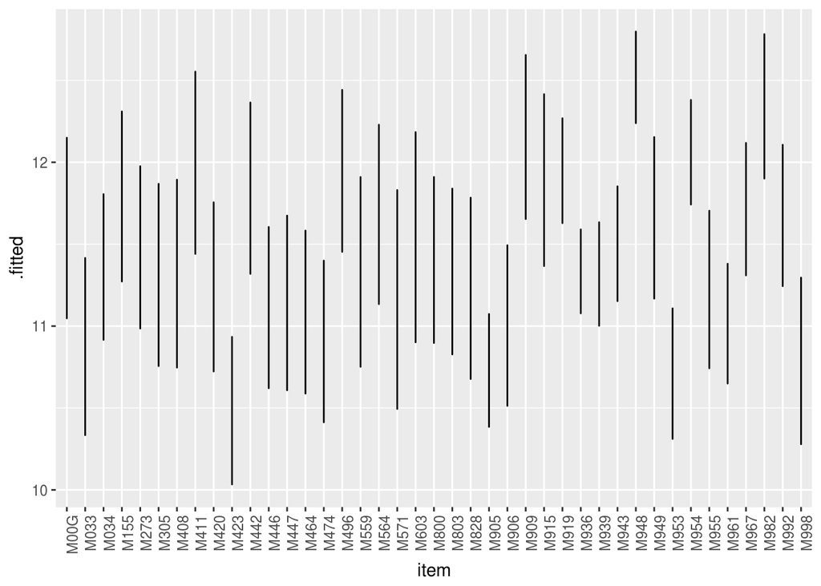

```r
dane_wykres2 <- augment(model)
g <- ggplot(dane_wykres2, aes(item, .fitted)) +geom_line()
g <- g + theme(legend.position="none", axis.text.x = element_text(angle = 90, hjust = 1))
g
```

#Zależność pozycji zadania od czasu jego rozwiązywania Kropkami zaznaczone są średnie wartości na każdej z pozycji.

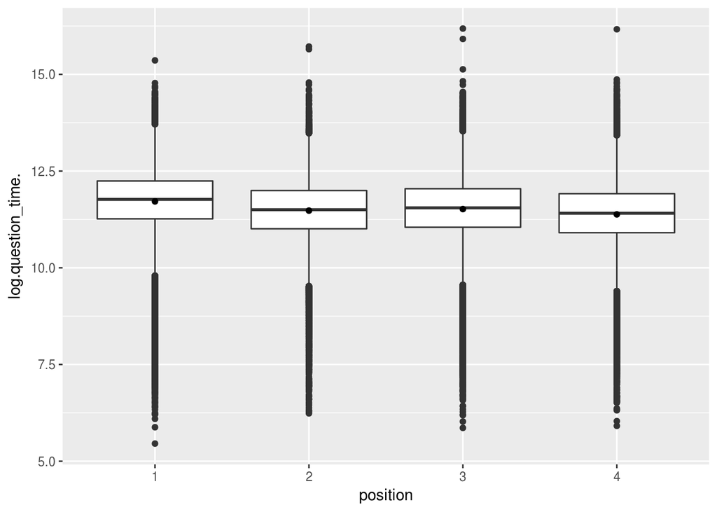

```r
ggplot(dane_wykres2, aes(position, log.question_time.)) + geom_boxplot()+
stat_summary(fun.y=mean, geom="point")
```

#Zależność kraju pochodzenia ucznia, a czasem rozwiązywania zadań

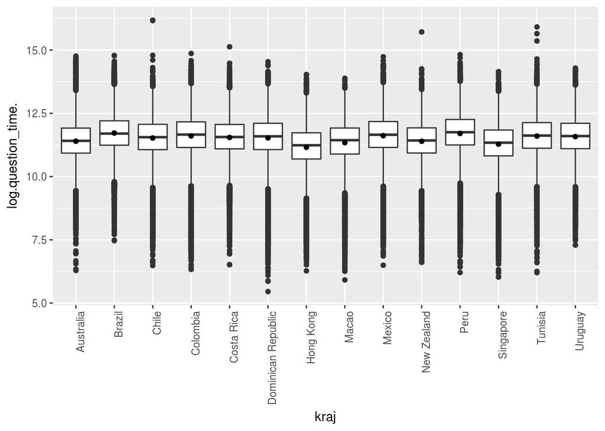

```r
ggplot(dane_wykres2, aes(kraj, log.question_time.)) + geom_boxplot()+
stat_summary(fun.y=mean, geom="point") + theme(legend.position="none", axis.text.x = element_text(angle = 90, hjust = 1))
```

#Zależność języka którym posługuje się uczeń, a czasem rozwiązywania zadań

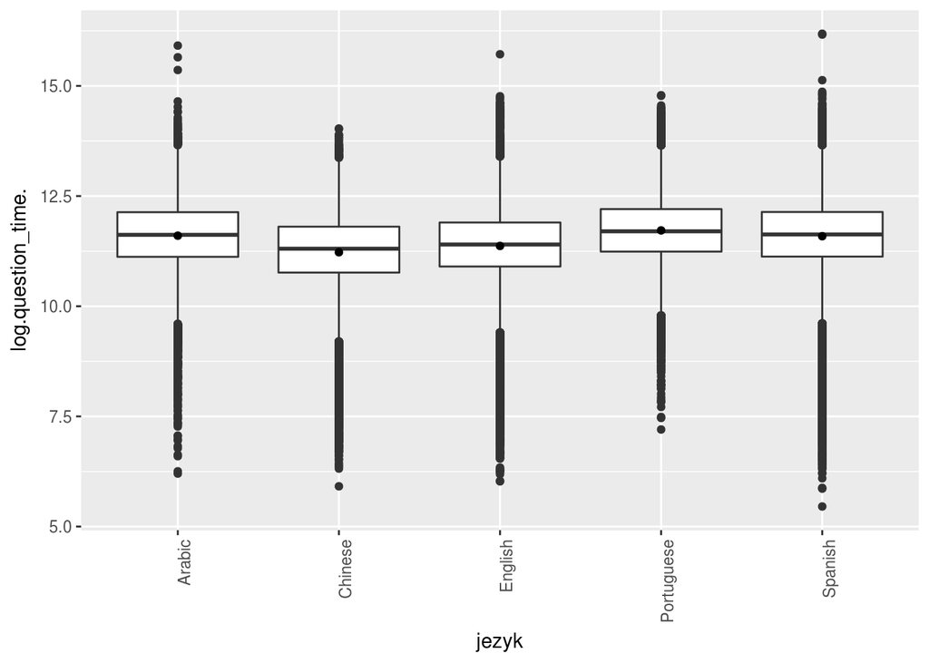

```r
ggplot(dane_wykres2, aes(jezyk, log.question_time.)) + geom_boxplot()+
stat_summary(fun.y=mean, geom="point") + theme(legend.position="none", axis.text.x = element_text(angle = 90, hjust = 1))
```

#Zależność płci ucznia, a czasem rozwiązywania zadań

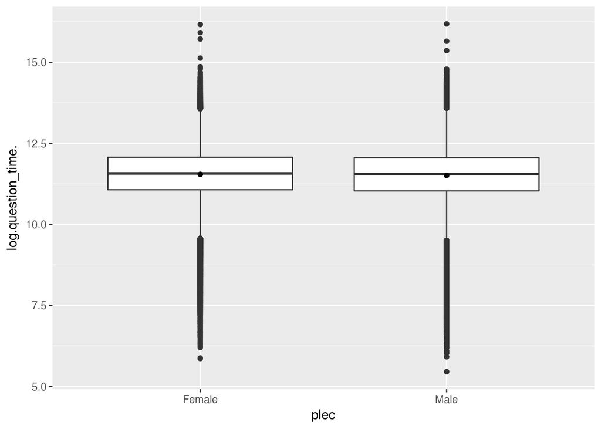

```r
ggplot(dane_wykres2, aes(plec, log.question_time.)) + geom_boxplot()+
stat_summary(fun.y=mean, geom="point")
```

# 6.Podsumowanie

Analizując model z etapu III ->lm(log(question_time)~(position/item)+jezyk+kraj+plec+wyksztalcenie_M+wyksztalcenie_O+czytanieCzasopismNaukowyc okazało się, że:  
* Wszystkie wybrane zmienne wykazały dużą istotność dla modelu  
* Największy wpływ mają zmienne jezyk, kraj, pozycja  
* O wiele mniejszy wpływ na zmienną objaśnianą mają zmienne wykształcenie, czytanie czasopism oraz płeć  
* Średnio uczniowie u któych językiem mówionym był Chiński i Angielski szybciej rozwiązywało zadania niż z pozostałymi językami.  
* Średnio kraje których kolonizatorem były Hiszpania gorzej radzą sobie z testami w porównaniu z tymi których kolonizatorem była Wielka Brytania  
* Według testów Post Hoc język Arabski grupuje się razem z Hiszpańskim, a w przypadku krajów można zauważyć pewne związki z położeniem geograficznym tzn. Nowa Zelandia grupuje się razem z Australią, a np. kraje należące do tzw. Ameryki Łacińskiej razem.  
* Wybrane test wykazały, że reszty nie są normalne  
* Wybrane testy wykazały, że model jest heteroskedastyczy

Nie zostały przedstawione wykresy diagnostyczne, ponieważ ze względu na dużą ilość danych nie były one czytelne.